# Introduction

Notebook to aggregate the running of models in the context of traceability between **test cases** and **bug reports**.

# Load Libraries and Datasets

```python
from mod_finder_util import mod_finder_util
mod_finder_util.add_modules_origin_search_path()

from modules.models_runner import tc_br_strat_runner
from modules.utils import aux_functions
from modules.utils import firefox_dataset_p2 as fd

import warnings; warnings.simplefilter('ignore')

testcases = fd.Datasets.read_testcases_df()
bugreports = fd.Datasets.read_selected_bugreports_df()
features = fd.Datasets.read_features_df()
```

```
TestCases.shape: (195, 12)
SelectedBugReports.shape: (91, 18)
Features.shape: (19, 8)
```

# Run All Models

## Intersec Strategy

```python
exp_vol_intersec_strat_runner = tc_br_strat_runner.TC_BR_Exp_Vol_Intersec_Strat_Runner()
exp_vol_intersec_strat_runner.execute()

evaluator_2 = exp_vol_intersec_strat_runner.get_evaluator()
evals_df_2 = exp_vol_intersec_strat_runner.get_evals_df()

MODELS = ['bm25','lsi','lda']
```

```
OracleExpertVolunteers_INTERSEC.shape: (195, 91)
TestCases.shape: (195, 12)
/Users/vb/tcc/trace-link-recovery-study/data/mozilla_firefox_v2/firefoxDataset/docs_english/BR/conceptnet/conceptnet_expanded_top_5_selected_bugreports_final.csv
SelectedBugReports.shape: (91, 18)
Running LSI Model ------
Running LDA Model -----
Running BM25 Model -----
Running ZeroR model -----
OracleExpertVolunteers_INTERSEC.shape: (195, 91)
major_target_artifact: [13, 20, 14, 25, 24, 22, 21, 23, 19, 18, 17, 16, 15]
Evaluating LSI Model -----
Evaluating LDA Model -----
Evaluating BM25 Model -----
Evaluating ZERO_R Model -----
```

### Results

```python
evals_df_2.head()
```

|  | model | ref_name | perc_precision | perc_recall | perc_fscore | sim_threshold | top | trace_links_df |
| --- | --- | --- | --- | --- | --- | --- | --- | --- |
| 0 | lsi | top_10_cosine_0.0 | 23.30 | 41.25 | 35.74 | 0.0 | 10.0 | Bug_Number 1248267 1248268 1257087 1264988... |
| 1 | lsi | top_10_cosine_0.1 | 23.30 | 41.25 | 35.74 | 0.1 | 10.0 | Bug_Number 1248267 1248268 1257087 1264988... |
| 2 | lsi | top_10_cosine_0.2 | 23.37 | 41.25 | 35.77 | 0.2 | 10.0 | Bug_Number 1248267 1248268 1257087 1264988... |
| 3 | lsi | top_10_cosine_0.3 | 23.40 | 41.25 | 35.79 | 0.3 | 10.0 | Bug_Number 1248267 1248268 1257087 1264988... |
| 4 | lsi | top_10_cosine_0.4 | 23.50 | 41.25 | 35.84 | 0.4 | 10.0 | Bug_Number 1248267 1248268 1257087 1264988... |

```python
evals_df_2 = evals_df_2[evals_df_2.top != 19.0]
aux_functions.highlight_df( evals_df_2[['model','perc_precision','perc_recall','perc_fscore','top']].groupby(['model','top']).mean())
```

| model | top | perc_precision | perc_recall | perc_fscore |
| --- | --- | --- | --- | --- |
| bm25 | 10.0 | 12.605000 | 17.257000 | 15.614000 |
|  | 20.0 | 11.010000 | 25.136000 | 18.403000 |
|  | 120.0 | 8.179000 | 43.522000 | 16.016000 |
| lda | 10.0 | 9.722000 | 15.800000 | 13.905000 |
|  | 20.0 | 8.601000 | 26.926000 | 18.521000 |
|  | 120.0 | 5.000000 | 53.794000 | 16.122000 |
| lsi | 10.0 | 30.441000 | 31.753000 | 28.972000 |
|  | 20.0 | 29.042000 | 49.008000 | 36.522000 |
|  | 120.0 | 23.368000 | 62.082000 | 28.462000 |
| zero_r | 10.0 | 21.980000 | 50.580000 | 40.140000 |
|  | 20.0 | 21.980000 | 50.580000 | 40.140000 |
|  | 120.0 | 21.980000 | 50.580000 | 40.140000 |

### Plots

evaluator_2.plot_evaluations_1(evals_df=evals_df_2, title='Exp-Vol Intersec Strategy')

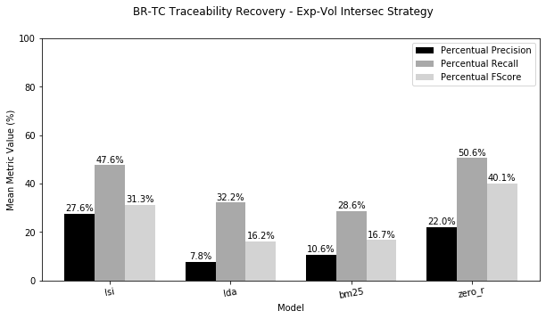

```python
evaluator_2.plot_evaluations_3(evals_df_2, title='BR-TC Traceability Recovery - Exp-Vol Intersec Strategy')
```

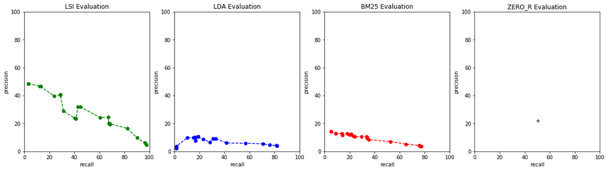

```python
evaluator_2.plot_evaluations_4(evals_df_2)
```

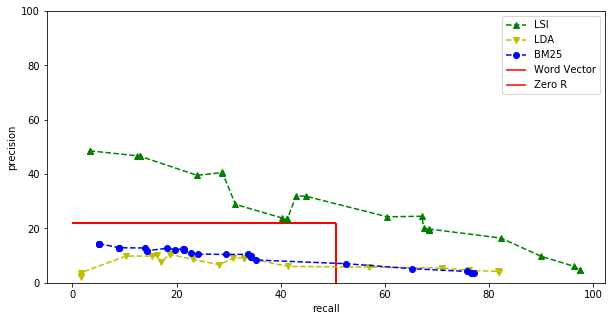

```python
evaluator_2.plot_evaluations_5(evals_df_2, models = ['lsi','lda','bm25'])
```

**Similarity Threshold Variation Analysis**

LSI

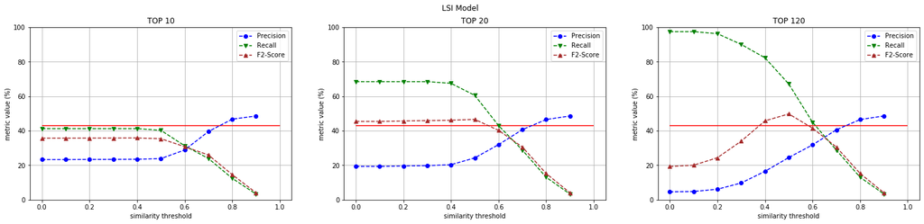

```python
evaluator_2.plot_evaluations_2_2('LSI Model', evals_df_2, 'lsi')
```

LDA

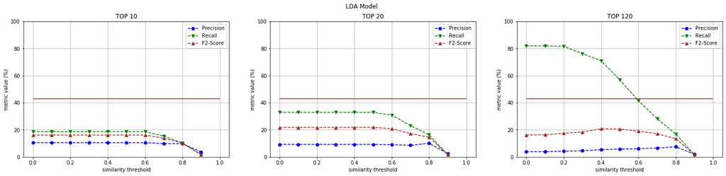

```python
evaluator_2.plot_evaluations_2_2('LDA Model', evals_df_2, 'lda')
```

BM25

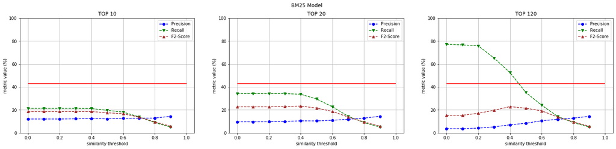

```python
evaluator_2.plot_evaluations_2_2('BM25 Model', evals_df_2, 'bm25')
```

### Oracle True Traces

```python
oracle_true_traces_inter = aux_functions.get_oracle_true_positives(exp_vol_intersec_strat_runner)
print('len(oracle_true_traces_inter): {}'.format(len(oracle_true_traces_inter)))
```

```
len(oracle_true_traces_inter): 514
```

#### Oracle

```python
aux_functions.highlight_df(exp_vol_intersec_strat_runner.get_evaluator().get_oracle_df().iloc[0:13,0:12])
```

| Bug_Number TC_Number | 1248267 | 1248268 | 1257087 | 1264988 | 1267480 | 1267501 | 1269348 | 1269485 | 1270274 | 1270983 | 1271607 | 1276120 |
| --- | --- | --- | --- | --- | --- | --- | --- | --- | --- | --- | --- | --- |
| 13 | 0 | 0 | 0 | 1 | 0 | 0 | 0 | 0 | 0 | 0 | 0 | 1 |
| 14 | 0 | 0 | 0 | 1 | 0 | 0 | 0 | 0 | 0 | 0 | 0 | 1 |
| 15 | 0 | 0 | 0 | 1 | 0 | 0 | 0 | 0 | 0 | 0 | 0 | 1 |
| 16 | 0 | 0 | 0 | 1 | 0 | 0 | 0 | 0 | 0 | 0 | 0 | 1 |
| 17 | 0 | 0 | 0 | 1 | 0 | 0 | 0 | 0 | 0 | 0 | 0 | 1 |
| 18 | 0 | 0 | 0 | 1 | 0 | 0 | 0 | 0 | 0 | 0 | 0 | 1 |
| 19 | 0 | 0 | 0 | 1 | 0 | 0 | 0 | 0 | 0 | 0 | 0 | 1 |
| 20 | 0 | 0 | 0 | 1 | 0 | 0 | 0 | 0 | 0 | 0 | 0 | 1 |
| 21 | 0 | 0 | 0 | 1 | 0 | 0 | 0 | 0 | 0 | 0 | 0 | 1 |
| 22 | 0 | 0 | 0 | 1 | 0 | 0 | 0 | 0 | 0 | 0 | 0 | 1 |
| 23 | 0 | 0 | 0 | 1 | 0 | 0 | 0 | 0 | 0 | 0 | 0 | 1 |
| 24 | 0 | 0 | 0 | 1 | 0 | 0 | 0 | 0 | 0 | 0 | 0 | 1 |
| 25 | 0 | 0 | 0 | 1 | 0 | 0 | 0 | 0 | 0 | 0 | 0 | 1 |

#### Similarity Matrices Analysis

##### **LDA**

```python
aux_functions.highlight_df(exp_vol_intersec_strat_runner.get_lda_model().get_sim_matrix().iloc[0:13,0:12])
```

| Bug_Number TC_Number | 1248267 | 1248268 | 1257087 | 1264988 | 1267480 | 1267501 | 1269348 | 1269485 | 1270274 | 1270983 | 1271607 | 1276120 |
| --- | --- | --- | --- | --- | --- | --- | --- | --- | --- | --- | --- | --- |
| 13 | 0.130446 | 0.263147 | 0.114941 | 0.111067 | 0.116084 | 0.111052 | 0.106001 | 0.098389 | 0.368500 | 0.324946 | 0.136970 | 0.293885 |
| 14 | 0.533742 | 0.556260 | 0.569868 | 0.546681 | 0.547410 | 0.568557 | 0.598606 | 0.570494 | 0.693132 | 0.423575 | 0.524981 | 0.410489 |
| 15 | 0.164355 | 0.295085 | 0.155640 | 0.242673 | 0.066676 | 0.161501 | 0.208000 | 0.156280 | 0.311170 | 0.200974 | 0.221405 | 0.240985 |
| 16 | 0.281128 | 0.467173 | 0.267278 | 0.484149 | 0.067275 | 0.305591 | 0.385933 | 0.295673 | 0.269181 | 0.340491 | 0.440223 | 0.477556 |
| 17 | 0.369603 | 0.582987 | 0.351446 | 0.671516 | 0.064379 | 0.416914 | 0.522698 | 0.403348 | 0.184217 | 0.445246 | 0.610048 | 0.661119 |
| 18 | 0.076835 | 0.179354 | 0.072502 | 0.086767 | 0.063214 | 0.055351 | 0.076781 | 0.055554 | 0.313520 | 0.129883 | 0.061719 | 0.098678 |
| 19 | 0.096908 | 0.187295 | 0.091389 | 0.079561 | 0.063378 | 0.055040 | 0.076521 | 0.055016 | 0.330140 | 0.162687 | 0.061357 | 0.087560 |
| 20 | 0.085756 | 0.154134 | 0.081089 | 0.074176 | 0.070824 | 0.075041 | 0.322373 | 0.059652 | 0.286111 | 0.108398 | 0.087754 | 0.075899 |
| 21 | 0.079116 | 0.154300 | 0.074945 | 0.068264 | 0.065558 | 0.066558 | 0.252924 | 0.054893 | 0.298837 | 0.100224 | 0.077198 | 0.069821 |
| 22 | 0.067684 | 0.151630 | 0.063773 | 0.058826 | 0.055534 | 0.048863 | 0.067692 | 0.047317 | 0.307882 | 0.085185 | 0.054493 | 0.060242 |
| 23 | 0.086305 | 0.145757 | 0.081676 | 0.144546 | 0.071387 | 0.061907 | 0.370024 | 0.059964 | 0.262287 | 0.109202 | 0.069010 | 0.076284 |
| 24 | 0.295560 | 0.341417 | 0.316122 | 0.324167 | 0.324980 | 0.294275 | 0.221830 | 0.300637 | 0.496007 | 0.262601 | 0.251631 | 0.240118 |
| 25 | 0.203275 | 0.270808 | 0.184786 | 0.217478 | 0.123671 | 0.194366 | 0.213886 | 0.171070 | 0.358934 | 0.249300 | 0.259706 | 0.312562 |

##### **LSI**

```python
aux_functions.highlight_df(exp_vol_intersec_strat_runner.get_lsi_model().get_sim_matrix().iloc[0:13,0:12])
```

| Bug_Number TC_Number | 1248267 | 1248268 | 1257087 | 1264988 | 1267480 | 1267501 | 1269348 | 1269485 | 1270274 | 1270983 | 1271607 | 1276120 |
| --- | --- | --- | --- | --- | --- | --- | --- | --- | --- | --- | --- | --- |
| 13 | 0.216661 | 0.285963 | 0.433714 | 0.592257 | 0.239972 | 0.323993 | 0.440658 | 0.236651 | 0.477615 | 0.354330 | 0.381963 | 0.207338 |
| 14 | 0.207432 | 0.283048 | 0.426729 | 0.570967 | 0.277984 | 0.256441 | 0.400126 | 0.151372 | 0.362567 | 0.321893 | 0.340710 | 0.155718 |
| 15 | 0.131294 | 0.212653 | 0.404058 | 0.602001 | 0.198999 | 0.233953 | 0.474674 | 0.163168 | 0.384901 | 0.289366 | 0.273404 | 0.140774 |
| 16 | 0.206364 | 0.241165 | 0.412728 | 0.565420 | 0.249677 | 0.278325 | 0.452222 | 0.177136 | 0.348115 | 0.325629 | 0.321804 | 0.133621 |
| 17 | 0.242521 | 0.237140 | 0.481273 | 0.491074 | 0.166867 | 0.390706 | 0.781334 | 0.241337 | 0.362077 | 0.389914 | 0.400753 | 0.206579 |
| 18 | 0.128214 | 0.198818 | 0.373292 | 0.573352 | 0.191554 | 0.253323 | 0.430373 | 0.173932 | 0.411980 | 0.295807 | 0.300730 | 0.185064 |
| 19 | 0.183961 | 0.250249 | 0.405709 | 0.567329 | 0.266134 | 0.336461 | 0.545481 | 0.210647 | 0.483299 | 0.325922 | 0.361724 | 0.235201 |
| 20 | 0.157688 | 0.234080 | 0.405292 | 0.492395 | 0.380675 | 0.327418 | 0.532994 | 0.165524 | 0.447861 | 0.288522 | 0.304263 | 0.197823 |
| 21 | 0.160644 | 0.238469 | 0.408529 | 0.513166 | 0.342673 | 0.309649 | 0.533673 | 0.158248 | 0.448227 | 0.285636 | 0.310097 | 0.193860 |
| 22 | 0.158954 | 0.226699 | 0.389005 | 0.519598 | 0.260639 | 0.270857 | 0.518760 | 0.149063 | 0.427440 | 0.263468 | 0.318670 | 0.188677 |
| 23 | 0.245101 | 0.371323 | 0.455848 | 0.595928 | 0.280321 | 0.282443 | 0.405500 | 0.149471 | 0.433408 | 0.289475 | 0.361035 | 0.211085 |
| 24 | 0.172560 | 0.192186 | 0.359870 | 0.510277 | 0.271272 | 0.342291 | 0.513626 | 0.287578 | 0.487389 | 0.287203 | 0.307256 | 0.355685 |
| 25 | 0.253973 | 0.302765 | 0.446051 | 0.583301 | 0.270218 | 0.408046 | 0.536199 | 0.279146 | 0.461556 | 0.360370 | 0.401391 | 0.258864 |

##### **BM25**

```python
#aux_functions.highlight_df(exp_vol_intersec_strat_runner.get_bm25_model().get_sim_matrix())
```

#### LDA Topics

```python
exp_vol_intersec_strat_runner.get_lda_model().print_topics()
```

```
Topic #0: awesom bar icon display site url search nan new state
Topic #1: widevin eme webm video support start load chang choos play
Topic #2: bookmark flash toolbar button websit enabl current empti area chang
Topic #3: inform ani check firefox save anoth display locat wa site
Topic #4: inform ani check firefox save anoth display locat wa site
Topic #5: lock pointerlock pointer api navig theme browser beta consol canva
Topic #6: scroll sure mous make apz true key config async issu
Topic #7: narrat reader speech text mode correctli icon button true set
Topic #8: inform ani check firefox save anoth display locat wa site
Topic #9: complet anoth nan basic toolbar abl user bookmark appear previou
Topic #10: reload websit popular video content render encount brows http navig
Topic #11: context menu page option open success imag thi bring link
Topic #12: zoom indic locat bar level page display default firefox remov
Topic #13: custom item warn exit verifi pref desktop toolbar allow default
Topic #14: pdf file child viewer mode valu list use drop basic
Topic #15: devic camera permiss share indic click icon tab start address
Topic #16: download panel dropmak button profil click complet open firefox toolbar
Topic #17: audio microphon stop snapshot screen field share choos select allow
Topic #18: flac sampl support file play audio tab correctli chang time
Topic #19: accur verifi wa time anim thi smooth mous valu wheel
```

### ZeroR Evaluation

```python
df = exp_vol_intersec_strat_runner.get_zeror_model().get_major_counts_df().iloc[0:20,:]
df.rename(columns={0:'TC ID',1:'num_BRs'})
```

|  | TC ID | num_BRs |
| --- | --- | --- |
| 0 | 13 | 20 |
| 7 | 20 | 20 |
| 1 | 14 | 20 |
| 12 | 25 | 20 |
| 11 | 24 | 20 |
| 9 | 22 | 20 |
| 8 | 21 | 20 |
| 10 | 23 | 20 |
| 6 | 19 | 20 |
| 5 | 18 | 20 |
| 4 | 17 | 20 |
| 3 | 16 | 20 |
| 2 | 15 | 20 |
| 147 | 160 | 4 |
| 155 | 168 | 4 |
| 154 | 167 | 4 |
| 153 | 166 | 4 |
| 152 | 165 | 4 |
| 151 | 164 | 4 |
| 150 | 163 | 4 |

```python
aux_functions.highlight_df(exp_vol_intersec_strat_runner.get_zeror_model().get_sim_matrix().iloc[0:20,:])
```

| Bug_Number TC_Number | 1248267 | 1248268 | 1257087 | 1264988 | 1267480 | 1267501 | 1269348 | 1269485 | 1270274 | 1270983 | 1271607 | 1276120 | 1277937 | 1278388 | 1279140 | 1279143 | 1279864 | 1281190 | 1281493 | 1282759 | 1283542 | 1285041 | 1285328 | 1287384 | 1287687 | 1287748 | 1287823 | 1289240 | 1289832 | … |
| --- | --- | --- | --- | --- | --- | --- | --- | --- | --- | --- | --- | --- | --- | --- | --- | --- | --- | --- | --- | --- | --- | --- | --- | --- | --- | --- | --- | --- | --- | --- |
| 13 | 1 | 1 | 1 | 1 | 1 | 1 | 1 | 1 | 1 | 1 | 1 | 1 | 1 | 1 | 1 | 1 | 1 | 1 | 1 | 1 | 1 | 1 | 1 | 1 | 1 | 1 | 1 | 1 | 1 | … |
| 14 | 1 | 1 | 1 | 1 | 1 | 1 | 1 | 1 | 1 | 1 | 1 | 1 | 1 | 1 | 1 | 1 | 1 | 1 | 1 | 1 | 1 | 1 | 1 | 1 | 1 | 1 | 1 | 1 | 1 | … |
| 15 | 1 | 1 | 1 | 1 | 1 | 1 | 1 | 1 | 1 | 1 | 1 | 1 | 1 | 1 | 1 | 1 | 1 | 1 | 1 | 1 | 1 | 1 | 1 | 1 | 1 | 1 | 1 | 1 | 1 | … |
| 16 | 1 | 1 | 1 | 1 | 1 | 1 | 1 | 1 | 1 | 1 | 1 | 1 | 1 | 1 | 1 | 1 | 1 | 1 | 1 | 1 | 1 | 1 | 1 | 1 | 1 | 1 | 1 | 1 | 1 | … |
| 17 | 1 | 1 | 1 | 1 | 1 | 1 | 1 | 1 | 1 | 1 | 1 | 1 | 1 | 1 | 1 | 1 | 1 | 1 | 1 | 1 | 1 | 1 | 1 | 1 | 1 | 1 | 1 | 1 | 1 | … |
| 18 | 1 | 1 | 1 | 1 | 1 | 1 | 1 | 1 | 1 | 1 | 1 | 1 | 1 | 1 | 1 | 1 | 1 | 1 | 1 | 1 | 1 | 1 | 1 | 1 | 1 | 1 | 1 | 1 | 1 | … |
| 19 | 1 | 1 | 1 | 1 | 1 | 1 | 1 | 1 | 1 | 1 | 1 | 1 | 1 | 1 | 1 | 1 | 1 | 1 | 1 | 1 | 1 | 1 | 1 | 1 | 1 | 1 | 1 | 1 | 1 | … |
| 20 | 1 | 1 | 1 | 1 | 1 | 1 | 1 | 1 | 1 | 1 | 1 | 1 | 1 | 1 | 1 | 1 | 1 | 1 | 1 | 1 | 1 | 1 | 1 | 1 | 1 | 1 | 1 | 1 | 1 | … |
| 21 | 1 | 1 | 1 | 1 | 1 | 1 | 1 | 1 | 1 | 1 | 1 | 1 | 1 | 1 | 1 | 1 | 1 | 1 | 1 | 1 | 1 | 1 | 1 | 1 | 1 | 1 | 1 | 1 | 1 | … |
| 22 | 1 | 1 | 1 | 1 | 1 | 1 | 1 | 1 | 1 | 1 | 1 | 1 | 1 | 1 | 1 | 1 | 1 | 1 | 1 | 1 | 1 | 1 | 1 | 1 | 1 | 1 | 1 | 1 | 1 | … |
| 23 | 1 | 1 | 1 | 1 | 1 | 1 | 1 | 1 | 1 | 1 | 1 | 1 | 1 | 1 | 1 | 1 | 1 | 1 | 1 | 1 | 1 | 1 | 1 | 1 | 1 | 1 | 1 | 1 | 1 | … |
| 24 | 1 | 1 | 1 | 1 | 1 | 1 | 1 | 1 | 1 | 1 | 1 | 1 | 1 | 1 | 1 | 1 | 1 | 1 | 1 | 1 | 1 | 1 | 1 | 1 | 1 | 1 | 1 | 1 | 1 | … |
| 25 | 1 | 1 | 1 | 1 | 1 | 1 | 1 | 1 | 1 | 1 | 1 | 1 | 1 | 1 | 1 | 1 | 1 | 1 | 1 | 1 | 1 | 1 | 1 | 1 | 1 | 1 | 1 | 1 | 1 | … |
| 26 | 0 | 0 | 0 | 0 | 0 | 0 | 0 | 0 | 0 | 0 | 0 | 0 | 0 | 0 | 0 | 0 | 0 | 0 | 0 | 0 | 0 | 0 | 0 | 0 | 0 | 0 | 0 | 0 | 0 | … |
| 27 | 0 | 0 | 0 | 0 | 0 | 0 | 0 | 0 | 0 | 0 | 0 | 0 | 0 | 0 | 0 | 0 | 0 | 0 | 0 | 0 | 0 | 0 | 0 | 0 | 0 | 0 | 0 | 0 | 0 | … |
| 28 | 0 | 0 | 0 | 0 | 0 | 0 | 0 | 0 | 0 | 0 | 0 | 0 | 0 | 0 | 0 | 0 | 0 | 0 | 0 | 0 | 0 | 0 | 0 | 0 | 0 | 0 | 0 | 0 | 0 | … |
| 29 | 0 | 0 | 0 | 0 | 0 | 0 | 0 | 0 | 0 | 0 | 0 | 0 | 0 | 0 | 0 | 0 | 0 | 0 | 0 | 0 | 0 | 0 | 0 | 0 | 0 | 0 | 0 | 0 | 0 | … |
| 30 | 0 | 0 | 0 | 0 | 0 | 0 | 0 | 0 | 0 | 0 | 0 | 0 | 0 | 0 | 0 | 0 | 0 | 0 | 0 | 0 | 0 | 0 | 0 | 0 | 0 | 0 | 0 | 0 | 0 | … |
| 31 | 0 | 0 | 0 | 0 | 0 | 0 | 0 | 0 | 0 | 0 | 0 | 0 | 0 | 0 | 0 | 0 | 0 | 0 | 0 | 0 | 0 | 0 | 0 | 0 | 0 | 0 | 0 | 0 | 0 | … |
| 32 | 0 | 0 | 0 | 0 | 0 | 0 | 0 | 0 | 0 | 0 | 0 | 0 | 0 | 0 | 0 | 0 | 0 | 0 | 0 | 0 | 0 | 0 | 0 | 0 | 0 | 0 | 0 | 0 | 0 | … |

### Approach Example

```python
aux_functions.highlight_df(exp_vol_intersec_strat_runner.get_lsi_model().get_sim_matrix().iloc[0:18,0:3])
```

| Bug_Number TC_Number | 1248267 | 1248268 | 1257087 |
| --- | --- | --- | --- |
| 13 | 0.216661 | 0.285963 | 0.433714 |
| 14 | 0.207432 | 0.283048 | 0.426729 |
| 15 | 0.131294 | 0.212653 | 0.404058 |
| 16 | 0.206364 | 0.241165 | 0.412728 |
| 17 | 0.242521 | 0.237140 | 0.481273 |
| 18 | 0.128214 | 0.198818 | 0.373292 |
| 19 | 0.183961 | 0.250249 | 0.405709 |
| 20 | 0.157688 | 0.234080 | 0.405292 |
| 21 | 0.160644 | 0.238469 | 0.408529 |
| 22 | 0.158954 | 0.226699 | 0.389005 |
| 23 | 0.245101 | 0.371323 | 0.455848 |
| 24 | 0.172560 | 0.192186 | 0.359870 |
| 25 | 0.253973 | 0.302765 | 0.446051 |
| 26 | 0.110224 | 0.230158 | 0.140726 |
| 27 | 0.194339 | 0.342061 | 0.198656 |
| 28 | 0.146080 | 0.272276 | 0.182406 |
| 29 | 0.247218 | 0.255196 | 0.203514 |
| 30 | 0.124751 | 0.192877 | 0.146413 |

```python
aux_functions.highlight_df(evals_df_2[(evals_df_2.model == 'lsi') & (evals_df_2.ref_name == 'top_10_cosine_0.0')].trace_links_df.values[0].iloc[0:18,0:3])
```

| Bug_Number TC_Number | 1248267 | 1248268 | 1257087 |
| --- | --- | --- | --- |
| 13 | 0 | 0 | 0 |
| 14 | 0 | 0 | 0 |
| 15 | 0 | 0 | 0 |
| 16 | 0 | 0 | 0 |
| 17 | 0 | 0 | 0 |
| 18 | 0 | 0 | 0 |
| 19 | 0 | 0 | 0 |
| 20 | 0 | 0 | 0 |
| 21 | 0 | 0 | 0 |
| 22 | 0 | 0 | 0 |
| 23 | 0 | 0 | 0 |
| 24 | 0 | 0 | 0 |
| 25 | 0 | 0 | 0 |
| 26 | 0 | 0 | 0 |
| 27 | 0 | 0 | 0 |
| 28 | 0 | 0 | 0 |
| 29 | 0 | 0 | 0 |
| 30 | 0 | 0 | 0 |

### Retrieved Traces - Similarity Threshold 0.0

```python
retrieved_traces_df = aux_functions.get_retrieved_traces_df(oracle=exp_vol_intersec_strat_runner.get_oracle(),
                                                            evals_df=evals_df_2,
                                                            top_values=[10,20,120],
                                                            sim_threshs=[0.0],
                                                            models=['lsi','lda','bm25'])
```

```python
import pandas as pd

df = retrieved_traces_df[['top','model','retrieved','num_TP','num_FP','num_FN','precision','recall','fscore']]
df = df.rename(columns={'num_FP':'FP','num_TP':'TP','num_FN':'FN'})
df[['TP','FP','FN']] = df[['TP','FP','FN']].apply(pd.to_numeric)
grouped = df.groupby(['top','model']).mean()

grouped.style.format({'model': lambda x : '---{}---'.format(x)})
#display(grouped)
```

[output not shown]

#### Traces Not Captured by Any Technique

```python
print('TOP 10 --------------------------')
all_captured_traces_t10_inter = aux_functions.get_captured_traces_union(top_value=10, retrieved_traces_df=retrieved_traces_df)
not_captured_traces_t10_inter = oracle_true_traces_inter - all_captured_traces_t10_inter
print('len(not_captured_traces): {}'.format(len(not_captured_traces_t10_inter)))
print('percent not_captured_traces: {}/{} * 100 : {:2.4}%'.format(len(not_captured_traces_t10_inter), len(oracle_true_traces_inter), len(not_captured_traces_t10_inter)/len(oracle_true_traces_inter)*100))

details_df_t10 = aux_functions.detail_features_tc_br(not_captured_traces_t10_inter, testcases, bugreports)
display(details_df_t10.groupby('tc_feat').count())

print('\n\nTOP 20 --------------------------')
all_captured_traces_t20_inter = aux_functions.get_captured_traces_union(top_value=20, retrieved_traces_df=retrieved_traces_df)
not_captured_traces_t20_inter = oracle_true_traces_inter - all_captured_traces_t20_inter
print('len(not_captured_traces): {}'.format(len(not_captured_traces_t20_inter)))
print('percent not_captured_traces: {}/{} * 100 : {:2.4}%'.format(len(not_captured_traces_t20_inter), len(oracle_true_traces_inter), len(not_captured_traces_t20_inter)/len(oracle_true_traces_inter)*100))

details_df_t20 = aux_functions.detail_features_tc_br(not_captured_traces_t20_inter, testcases, bugreports)
display(details_df_t20.groupby('tc_feat').count())

print('\n\nTOP 120 --------------------------')
all_captured_traces_t120_inter = aux_functions.get_captured_traces_union(top_value=120, retrieved_traces_df=retrieved_traces_df)
not_captured_traces_t120_inter = oracle_true_traces_inter - all_captured_traces_t120_inter
print('len(not_captured_traces): {}'.format(len(not_captured_traces_t120_inter)))
print('percent not_captured_traces: {}/{} * 100 : {:2.4}%'.format(len(not_captured_traces_t120_inter), len(oracle_true_traces_inter), len(not_captured_traces_t120_inter)/len(oracle_true_traces_inter)*100))
print(not_captured_traces_t120_inter)

details_df_t120 = aux_functions.detail_features_tc_br(not_captured_traces_t120_inter, testcases, bugreports)
display(details_df_t120.groupby('tc_feat').count())
```

```
TOP 10 --------------------------
len(not_captured_traces): 236
percent not_captured_traces: 236/514 * 100 : 45.91%
```

| tc_feat | tc | br | br_summary |
| --- | --- | --- | --- |
| Browser Customization | 7 | 7 | 7 |
| Context Menu | 53 | 53 | 53 |
| Downloads Dropmaker | 14 | 14 | 14 |
| Indicator for device permissions | 11 | 11 | 11 |
| New Awesome Bar | 137 | 137 | 137 |
| PDF Viewer | 1 | 1 | 1 |
| Zoom Indicator | 13 | 13 | 13 |

```
TOP 20 --------------------------
len(not_captured_traces): 119
percent not_captured_traces: 119/514 * 100 : 23.15%
```

| tc_feat | tc | br | br_summary |
| --- | --- | --- | --- |
| Browser Customization | 4 | 4 | 4 |
| Context Menu | 23 | 23 | 23 |
| Downloads Dropmaker | 6 | 6 | 6 |
| Indicator for device permissions | 3 | 3 | 3 |
| New Awesome Bar | 78 | 78 | 78 |
| Zoom Indicator | 5 | 5 | 5 |

```
TOP 120 --------------------------
len(not_captured_traces): 1
percent not_captured_traces: 1/514 * 100 : 0.1946%
{(15, 1276120)}
```

| tc_feat | tc | br | br_summary |
| --- | --- | --- | --- |
| New Awesome Bar | 1 | 1 | 1 |

##### Missed Traces Detailed

TOP 10

```python
import pandas as pd

lda_model = exp_vol_intersec_strat_runner.get_lda_model()
lsi_model = exp_vol_intersec_strat_runner.get_lsi_model()
bm25_model = exp_vol_intersec_strat_runner.get_bm25_model()

df = pd.DataFrame(columns=['mrw_tcs','mrw_brs'], index=['lda_t10','lsi_t10','bm25_t10',
                                                        'lda_t20','lsi_t20','bm25_t20',
                                                        'lda_t120','lsi_t120','bm25_t120'])

lda_mrw_tc_t10, lda_mrw_br_t10 = aux_functions.get_mrw_traces_set(not_captured_traces_t10_inter, lda_model)
lda_mrw_tc_t20, lda_mrw_br_t20 = aux_functions.get_mrw_traces_set(not_captured_traces_t20_inter, lda_model)
lda_mrw_tc_t120, lda_mrw_br_t120 = aux_functions.get_mrw_traces_set(not_captured_traces_t120_inter, lda_model)

lsi_mrw_tc_t10, lsi_mrw_br_t10 = aux_functions.get_mrw_traces_set(not_captured_traces_t10_inter, lsi_model)
lsi_mrw_tc_t20, lsi_mrw_br_t20 = aux_functions.get_mrw_traces_set(not_captured_traces_t20_inter, lsi_model)
lsi_mrw_tc_t120, lsi_mrw_br_t120 = aux_functions.get_mrw_traces_set(not_captured_traces_t120_inter, lsi_model)

bm25_mrw_tc_t10, bm25_mrw_br_t10 = aux_functions.get_mrw_traces_set(not_captured_traces_t10_inter, bm25_model)
bm25_mrw_tc_t20, bm25_mrw_br_t20 = aux_functions.get_mrw_traces_set(not_captured_traces_t20_inter, bm25_model)
bm25_mrw_tc_t120, bm25_mrw_br_t120 = aux_functions.get_mrw_traces_set(not_captured_traces_t120_inter, bm25_model)

df.at['lda_t10','mrw_tcs'] = lda_mrw_tc_t10
df.at['lda_t10','mrw_brs'] = lda_mrw_br_t10
df.at['lda_t20','mrw_tcs'] = lda_mrw_tc_t20
df.at['lda_t20','mrw_brs'] = lda_mrw_br_t20
df.at['lda_t120','mrw_tcs'] = lda_mrw_tc_t120
df.at['lda_t120','mrw_brs'] = lda_mrw_br_t120


df.at['lsi_t10','mrw_tcs'] = lsi_mrw_tc_t10
df.at['lsi_t10','mrw_brs'] = lsi_mrw_br_t10
df.at['lsi_t20','mrw_tcs'] = lsi_mrw_tc_t20
df.at['lsi_t20','mrw_brs'] = lsi_mrw_br_t20
df.at['lsi_t120','mrw_tcs'] = lsi_mrw_tc_t120
df.at['lsi_t120','mrw_brs'] = lsi_mrw_br_t120

df.at['bm25_t10','mrw_tcs'] = bm25_mrw_tc_t10
df.at['bm25_t10','mrw_brs'] = bm25_mrw_br_t10
df.at['bm25_t20','mrw_tcs'] = bm25_mrw_tc_t20
df.at['bm25_t20','mrw_brs'] = bm25_mrw_br_t20
df.at['bm25_t120','mrw_tcs'] = bm25_mrw_tc_t120
df.at['bm25_t120','mrw_brs'] = bm25_mrw_br_t120

display(df[df.index.str.contains('lda')])
display(df[df.index.str.contains('lsi')])
display(df[df.index.str.contains('bm25')])
```

|  | mrw_tcs | mrw_brs |
| --- | --- | --- |
| lda_t10 | [(awesom, 125), (bar, 106), (icon, 104), (display, 91), (site, 67), (menu, 55)] | [(check, 99), (block, 72), (search, 62), (current, 54), (open, 51), (tab, 46)] |
| lda_t20 | [(awesom, 74), (bar, 58), (icon, 48), (display, 48), (site, 32), (search, 26)] | [(check, 59), (current, 41), (tab, 30), (open, 29), (block, 25), (mode, 23)] |
| lda_t120 | [(search, 1), (display, 1), (indic, 1), (awesom, 1), (ensur, 1), (bar, 1)] | [(step, 1), (run, 1), (window, 1), (open, 1), (mode, 1), (tri, 1)] |

|  | mrw_tcs | mrw_brs |
| --- | --- | --- |
| lsi_t10 | [(awesome, 125), (bar, 118), (icon, 102), (site, 67), (menu, 55), (context, 53)] | [(check, 79), (clear, 75), (block, 72), (result, 54), (current, 54), (search, 54)] |
| lsi_t20 | [(awesome, 74), (bar, 62), (icon, 47), (site, 32), (context, 23), (menu, 23)] | [(check, 54), (clear, 43), (current, 41), (tab, 30), (block, 25), (category, 23)] |
| lsi_t120 | [(search, 1), (displayed, 1), (indicator, 1), (awesome, 1), (ensure, 1), (state, 1)] | [(clear, 1), (outside, 1), (step, 1), (category, 1), (focus, 1), (downward, 1)] |

|  | mrw_tcs | mrw_brs |
| --- | --- | --- |
| bm25_t10 | [(bar, 157), (display, 133), (icon, 103), (page, 93), (open, 89), (click, 85)] | [(firefox, 236), (open, 166), (bar, 81), (tab, 77), (search, 62), (click, 47)] |
| bm25_t20 | [(bar, 84), (display, 73), (icon, 48), (page, 45), (click, 42), (open, 40)] | [(firefox, 119), (open, 88), (tab, 54), (bar, 37), (mode, 26), (window, 25)] |
| bm25_t120 | [(display, 1), (bar, 1), (indic, 1), (search, 1), (awesom, 1), (new, 1)] | [(open, 1), (window, 1), (go, 1), (firefox, 1), (mode, 1), (move, 1)] |

```python
nab_feat_num = features[features.feat_name == 'new_awesome_bar'].Feature_Number.values[0]
nab_tcs_nums = testcases[testcases.Feature_ID == nab_feat_num].TC_Number.values
print(nab_tcs_nums)
nab_brs_list = [br for tc,br in not_captured_traces_t10_inter if tc in nab_tcs_nums]
print(nab_brs_list)
print(len(nab_brs_list))
```

```
[13 14 15 16 17 18 19 20 21 22 23 24 25]
[1276120, 1334844, 1296366, 1296366, 1276120, 1365887, 1276120, 1294733, 1297976, 1337682, 1311998, 1365887, 1365887, 1365887, 1279143, 1279864, 1279143, 1296366, 1357458, 1296366, 1301421, 1279864, 1296366, 1279143, 1264988, 1353831, 1296366, 1279864, 1296366, 1279864, 1352539, 1279864, 1297374, 13…
137
```

**LDA Model**

```python
aux_functions.rank_tc_br_matrix([nab_brs_list[0]], exp_vol_intersec_strat_runner.get_lda_model().get_sim_matrix(), 10)
```

| Bug_Number TC_Number | 1276120 |
| --- | --- |
| 181 | 0.721398 |
| 182 | 0.723043 |
| 183 | 0.719388 |
| 184 | 0.726169 |
| 189 | 0.754495 |
| 190 | 0.722698 |
| 191 | 0.714575 |
| 192 | 0.723500 |
| 194 | 0.722177 |
| 195 | 0.719243 |

```python
aux_functions.rank_tc_br_matrix([nab_brs_list[-1]], exp_vol_intersec_strat_runner.get_lda_model().get_sim_matrix(), 10)
```

| Bug_Number TC_Number | 1337682 |
| --- | --- |
| 181 | 0.727594 |
| 182 | 0.729309 |
| 183 | 0.726143 |
| 184 | 0.732185 |
| 189 | 0.779270 |
| 190 | 0.729097 |
| 191 | 0.719804 |
| 192 | 0.729811 |
| 194 | 0.728547 |
| 195 | 0.726014 |

```python
docs_feats = exp_vol_intersec_strat_runner.get_lda_model().docs_feats_df
docs_feats[docs_feats.index.isin(list(range(13,26)) + [nab_brs_list[0]] + [nab_brs_list[-1]])]
```

|  | mrw | dl |
| --- | --- | --- |
| 13 | [awesom, bar, state, search, set, launch] | 24 |
| 14 | [drop, search, ensur, url, link, awesom] | 62 |
| 15 | [search, display, indic, awesom, ensur, bar] | 27 |
| 16 | [search, ensur, awesom, link, drop, display] | 34 |
| 17 | [tab, devic, ensur, link, icon, display] | 54 |
| 18 | [awesom, bar, url, state, correctli, search] | 23 |
| 19 | [icon, awesom, bar, display, support, left] | 22 |
| 20 | [lock, icon, site, http, awesom, display] | 38 |
| 21 | [icon, site, lock, awesom, display, bar] | 35 |
| 22 | [inform, icon, bar, awesom, left, site] | 32 |
| 23 | [drop, arrow, bar, awesom, list, display] | 34 |
| 24 | [reader, mode, icon, bar, awesom, site] | 38 |
| 25 | [reload, awesom, bar, icon, display, right] | 27 |
| 1276120 | [step, run, window, open, mode, tri] | 139 |
| 1337682 | [enter, current, speech, check, address, choos] | 138 |

**LSI**

```python
aux_functions.rank_tc_br_matrix([nab_brs_list[0]], exp_vol_intersec_strat_runner.get_lsi_model().get_sim_matrix(), 10)
```

| Bug_Number TC_Number | 1276120 |
| --- | --- |
| 62 | 0.505907 |
| 104 | 0.675976 |
| 105 | 0.781756 |
| 106 | 0.816931 |
| 107 | 0.689440 |
| 108 | 0.736126 |
| 109 | 0.761169 |
| 119 | 0.474503 |
| 126 | 0.511885 |
| 186 | 0.534627 |

```python
aux_functions.rank_tc_br_matrix([nab_brs_list[-1]], exp_vol_intersec_strat_runner.get_lsi_model().get_sim_matrix(), 10)
```

| Bug_Number TC_Number | 1337682 |
| --- | --- |
| 29 | 0.637977 |
| 62 | 0.550528 |
| 64 | 0.539838 |
| 65 | 0.544101 |
| 68 | 0.533946 |
| 80 | 0.521769 |
| 85 | 0.597767 |
| 88 | 0.524538 |
| 119 | 0.560988 |
| 186 | 0.577262 |

**BM25**

```python
aux_functions.rank_tc_br_matrix([nab_brs_list[0]], exp_vol_intersec_strat_runner.get_bm25_model().get_sim_matrix(), 10)
```

| Bug_Number TC_Number | 1276120 |
| --- | --- |
| 29 | 0.810602 |
| 109 | 0.664333 |
| 110 | 0.641510 |
| 126 | 0.691456 |
| 127 | 0.858145 |
| 128 | 0.858849 |
| 129 | 0.820474 |
| 157 | 1.000000 |
| 158 | 0.791010 |
| 176 | 0.671490 |

```python
aux_functions.rank_tc_br_matrix([nab_brs_list[-1]], exp_vol_intersec_strat_runner.get_bm25_model().get_sim_matrix(), 10)
```

| Bug_Number TC_Number | 1337682 |
| --- | --- |
| 29 | 0.675297 |
| 61 | 0.890084 |
| 65 | 0.691190 |
| 80 | 0.618227 |
| 128 | 0.818398 |
| 156 | 0.625265 |
| 180 | 0.808863 |
| 191 | 0.589889 |
| 193 | 1.000000 |
| 204 | 0.594596 |

TOP 120

```python
aux_functions.detail_features_tc_br(not_captured_traces_t120_inter, testcases=testcases, bugreports=bugreports).sort_values(by='tc')
```

|  | tc | tc_feat | br | br_summary |
| --- | --- | --- | --- | --- |
| 0 | 15 | New Awesome Bar | 1276120 | Autocomplete suggestions just don't go away after Win+Down |

- BR_1276720 (New Awesome Bar): the description doesn't help, there is no relevant keywords in the content. The reporter used some words incorrectly, such as "searchbar" and "urlbar, which difficult the techniques task.
- BR_1279143 (New Awesome Bar): the description contains the word "awesomebar" written incorrectly. The presence of incorrect words requires the use of complementary techniques to detect and correct these mistakes before the query (bug report) be submitted to the technique, so a relevant result may be returned.
- BR_1296366 (New Awesome Bar): the bug description is very brief and the title contains the word "awesomebar", also written incorrecly, such as in the previous bug;
- BR_1293308 (New Awesome Bar): the bug reporter provided a technical description and used technical words, such as "urlbar", and a synonym "location bar", both not used in the test cases descriptions;
- BR_1270983 (Context Menu): this bug was probably reported automatically as result of automatic test failure. Despite the presence of the word "contextmenu" in the title, the technique were not able to link it with the test cases of this system feature. This may happened due to the writting, again "incorrect" into the bug description.
- BR_1432915 (Downloads Dropmaker): this bug report lacks important fields, such as the steps to reproduce and expected results. The reporter provided a very short description about a technical issue while downloading files. Despite the presence of the keyword "downloading", the techniques were not able to link this bug report with the test cases that have a shorter description.

```python
aux_functions.rank_tc_br_matrix([1299458], exp_vol_intersec_strat_runner.get_lsi_model().get_sim_matrix(), 120)
```

| Bug_Number TC_Number | 1299458 |
| --- | --- |
| 13 | 0.642635 |
| 14 | 0.633938 |
| 15 | 0.588308 |
| 16 | 0.656955 |
| 17 | 0.627368 |
| ... | ... |
| 195 | 0.174150 |
| 199 | 0.120277 |
| 204 | 0.155978 |
| 205 | 0.181685 |
| 207 | 0.133060 |

120 rows × 1 columns

#### Traces Captured by Every Technique

```python
print('TOP 10 -----------------------')
traces_captured_by_all_t10_inter = aux_functions.get_captured_traces_intersec(10, retrieved_traces_df)
print('len(traces_captured_by_all): {}'.format(len(traces_captured_by_all_t10_inter)))
print('percent traces_captured_by_all: {}/{} * 100 : {:2.4}%'.format(len(traces_captured_by_all_t10_inter), len(oracle_true_traces_inter), len(traces_captured_by_all_t10_inter)/len(oracle_true_traces_inter) *100))

details_df_t10 = aux_functions.detail_features_tc_br(traces_captured_by_all_t10_inter, testcases, bugreports)
display(details_df_t10.groupby('tc_feat').count())

print('\n\nTOP 20 -----------------------')
traces_captured_by_all_t20_inter = aux_functions.get_captured_traces_intersec(20, retrieved_traces_df)
print('len(traces_captured_by_all): {}'.format(len(traces_captured_by_all_t20_inter)))
print('percent traces_captured_by_all: {}/{} * 100 : {:2.4}%'.format(len(traces_captured_by_all_t20_inter), len(oracle_true_traces_inter), len(traces_captured_by_all_t20_inter)/len(oracle_true_traces_inter) *100))

details_df_t20 = aux_functions.detail_features_tc_br(traces_captured_by_all_t20_inter, testcases, bugreports)
display(details_df_t20.groupby('tc_feat').count())

print('\n\nTOP 120 -----------------------')
traces_captured_by_all_t120_inter = aux_functions.get_captured_traces_intersec(120, retrieved_traces_df)
print('len(traces_captured_by_all): {}'.format(len(traces_captured_by_all_t120_inter)))
print('percent traces_captured_by_all: {}/{} * 100 : {:2.4}%'.format(len(traces_captured_by_all_t120_inter), len(oracle_true_traces_inter), len(traces_captured_by_all_t120_inter)/len(oracle_true_traces_inter) *100))

details_df_t120 = aux_functions.detail_features_tc_br(traces_captured_by_all_t120_inter, testcases, bugreports)
display(details_df_t120.groupby('tc_feat').count())
```

```
TOP 10 -----------------------
len(traces_captured_by_all): 32
percent traces_captured_by_all: 32/514 * 100 : 6.226%
```

| tc_feat | tc | br | br_summary |
| --- | --- | --- | --- |
| Browser Customization | 1 | 1 | 1 |
| Context Menu | 4 | 4 | 4 |
| Downloads Dropmaker | 6 | 6 | 6 |
| Indicator for device permissions | 8 | 8 | 8 |
| New Awesome Bar | 13 | 13 | 13 |

```
TOP 20 -----------------------
len(traces_captured_by_all): 89
percent traces_captured_by_all: 89/514 * 100 : 17.32%
```

| tc_feat | tc | br | br_summary |
| --- | --- | --- | --- |
| Browser Customization | 1 | 1 | 1 |
| Context Menu | 13 | 13 | 13 |
| Downloads Dropmaker | 32 | 32 | 32 |
| Indicator for device permissions | 22 | 22 | 22 |
| New Awesome Bar | 20 | 20 | 20 |
| PDF Viewer | 1 | 1 | 1 |

```
TOP 120 -----------------------
len(traces_captured_by_all): 355
percent traces_captured_by_all: 355/514 * 100 : 69.07%
```

| tc_feat | tc | br | br_summary |
| --- | --- | --- | --- |
| Browser Customization | 6 | 6 | 6 |
| Context Menu | 91 | 91 | 91 |
| Downloads Dropmaker | 68 | 68 | 68 |
| Indicator for device permissions | 48 | 48 | 48 |
| New Awesome Bar | 113 | 113 | 113 |
| PDF Viewer | 8 | 8 | 8 |
| Zoom Indicator | 21 | 21 | 21 |

#### Techniques Evaluation

```python
retrieved_traces_df[['top','sim_thresh','model','num_TP','num_FP','num_FN','precision','recall','fscore']].head(50)
```

[output not shown]

#### True Positives Analysis

```python
bm25_tp_set_t10, lsi_tp_set_t10, lda_tp_set_t10 = aux_functions.get_traces_set(retrieved_traces_df, MODELS, 10, 'TP')
bm25_tp_set_t20, lsi_tp_set_t20, lda_tp_set_t20 = aux_functions.get_traces_set(retrieved_traces_df, MODELS, 20, 'TP')
bm25_tp_set_t120, lsi_tp_set_t120, lda_tp_set_t120 = aux_functions.get_traces_set(retrieved_traces_df, MODELS, 120, 'TP')
#aux_functions.plot_venn_diagrams(TOP, bm25_tp_set_t5, lsi_tp_set_t5, lda_tp_set_t5, 'True Positives')
```

##### Exclusive Traces

```python
import pandas as pd

print("TOP 10 ------------------------------")
bm25_tp_exc_set_t10, lsi_tp_exc_set_t10, lda_tp_exc_set_t10 =  aux_functions.get_exclusive_traces_expanded(bm25_tp_set_t10, lsi_tp_set_t10, lda_tp_set_t10, traces_type='TP')

print("\n\nTOP 20 ------------------------------")
bm25_tp_exc_set_t20, lsi_tp_exc_set_t20, lda_tp_exc_set_t20 =  aux_functions.get_exclusive_traces_expanded(bm25_tp_set_t20, lsi_tp_set_t20, lda_tp_set_t20, traces_type='TP')

print("\n\nTOP 120 -------------------------------")
bm25_tp_exc_set_t120, lsi_tp_exc_set_t120, lda_tp_exc_set_t120 =  aux_functions.get_exclusive_traces_expanded(bm25_tp_set_t120, lsi_tp_set_t120, lda_tp_set_t120, traces_type='TP')

df = pd.DataFrame(index=['TOP 10', 'TOP 20', 'TOP 120'], columns=['BM25','LSI','LDA'])

df.at['TOP 10','BM25'] = len(bm25_tp_exc_set_t10)
df.at['TOP 20','BM25'] = len(bm25_tp_exc_set_t20)
df.at['TOP 120','BM25'] = len(bm25_tp_exc_set_t120)

df.at['TOP 10','LSI'] = len(lsi_tp_exc_set_t10)
df.at['TOP 20','LSI'] = len(lsi_tp_exc_set_t20)
df.at['TOP 120','LSI'] = len(lsi_tp_exc_set_t120)

df.at['TOP 10','LDA'] = len(lda_tp_exc_set_t10)
df.at['TOP 20','LDA'] = len(lda_tp_exc_set_t20)
df.at['TOP 120','LDA'] = len(lda_tp_exc_set_t120)

print()

df
```

```
TOP 10 ------------------------------


len(bm25_exc_set): 26
len(lsi_exc_set): 116
len(lda_exc_set): 28


TOP 20 ------------------------------


len(bm25_exc_set): 17
len(lsi_exc_set): 148
len(lda_exc_set): 17


TOP 120 -------------------------------


len(bm25_exc_set): 0
len(lsi_exc_set): 61
len(lda_exc_set): 1
```

|  | BM25 | LSI | LDA |
| --- | --- | --- | --- |
| TOP 10 | 26 | 116 | 28 |
| TOP 20 | 17 | 148 | 17 |
| TOP 120 | 0 | 61 | 1 |

Top 120 Exclusive True Positives

```python
print('Top 120 LSI Exclusive TP Traces')
display(aux_functions.detail_features_tc_br_groups(lsi_tp_exc_set_t120, testcases=testcases, bugreports=bugreports).sort_values(by='tc_feat'))
print('---------')

print('Top 120 LDA Exclusive TP Traces')
display(aux_functions.detail_features_tc_br_groups(lda_tp_exc_set_t120, testcases=testcases, bugreports=bugreports).sort_values(by='tc_feat'))
print('---------')

print('Top 120 BM25 Exclusive TP Traces')
display(aux_functions.detail_features_tc_br_groups(bm25_tp_exc_set_t120, testcases=testcases, bugreports=bugreports).sort_values(by='tc_feat'))
print('---------')
```

```
Top 120 LSI Exclusive TP Traces
```

|  | br | br_summary | tc_feat | tc_ids |
| --- | --- | --- | --- | --- |
| 0 | 1264988 | Scrollbar appears for a moment in the new Awesomebar Resultlist | New Awesome Bar | [18, 20, 22, 21] |
| 1 | 1276120 | Autocomplete suggestions just don't go away after Win+Down | New Awesome Bar | [22, 13, 18, 19, 23, 20, 25, 21] |
| 2 | 1279143 | color indicator missing when "File -> New Container Tab" without any windows opened | New Awesome Bar | [21, 20, 19, 18, 22] |
| 3 | 1279864 | The new location bar autocomplete drop down menu starting from 48 has serious performance issue and often blocks user's <Enter> input | New Awesome Bar | [25, 22, 19, 20, 21] |
| 4 | 1293308 | System font setting respected by location bar but ignored by location bar's autocomplete drop-down list | New Awesome Bar | [15, 22, 19, 20, 24, 21, 18] |
| 5 | 1296366 | Ctrl+Click awesomebar entry with "Switch to Tab" doesn't open new tab | New Awesome Bar | [18, 19, 22, 23, 20, 21] |
| 6 | 1301421 | browser.fixup.dns_first_for_single_words prevents location bar search suggestions even when there's more than one token and/or the first token is not a single word | New Awesome Bar | [23, 22, 21, 25, 20, 19] |
| 7 | 1334844 | Address bar uses most recently entered URL, not URL in bar, after using CTRL+ENTER | New Awesome Bar | [20, 21, 13] |
| 8 | 1337682 | using ctrl / shift + enter seems to save the URL to a hidden clipboard that populates when hitting enter (hard to describe). | New Awesome Bar | [21, 22, 23, 19, 20] |
| 9 | 1339497 | firefox tries to load incorrect url if urlbar autocomplete suggests first-two-letters-duplicated hosts when input url contains % encoded components | New Awesome Bar | [20, 15, 25, 19, 21] |
| 10 | 1365887 | Can't open resource:///modules/ from the location bar | New Awesome Bar | [21, 25, 20, 15, 19, 18, 22] |

```
---------
Top 120 LDA Exclusive TP Traces
```

|  | br | br_summary | tc_feat | tc_ids |
| --- | --- | --- | --- | --- |
| 0 | 1276120 | Autocomplete suggestions just don't go away after Win+Down | New Awesome Bar | [16] |

```
---------
Top 120 BM25 Exclusive TP Traces
```

|  | br | br_summary | tc_feat | tc_ids |
| --- | --- | --- | --- | --- |

```python
details_df_t10 = aux_functions.detail_features_tc_br(lsi_tp_exc_set_t10, testcases, bugreports)
display(details_df_t10.groupby('tc_feat').count())

details_df_t20 = aux_functions.detail_features_tc_br(lsi_tp_exc_set_t20, testcases, bugreports)
display(details_df_t20.groupby('tc_feat').count())

details_df_t120 = aux_functions.detail_features_tc_br(lsi_tp_exc_set_t120, testcases, bugreports)
display(details_df_t120.groupby('tc_feat').count())
```

| tc_feat | tc | br | br_summary |
| --- | --- | --- | --- |
| Browser Customization | 2 | 2 | 2 |
| Context Menu | 13 | 13 | 13 |
| Downloads Dropmaker | 12 | 12 | 12 |
| Indicator for device permissions | 7 | 7 | 7 |
| New Awesome Bar | 73 | 73 | 73 |
| PDF Viewer | 5 | 5 | 5 |
| Zoom Indicator | 4 | 4 | 4 |

| tc_feat | tc | br | br_summary |
| --- | --- | --- | --- |
| Browser Customization | 4 | 4 | 4 |
| Context Menu | 13 | 13 | 13 |
| Downloads Dropmaker | 7 | 7 | 7 |
| Indicator for device permissions | 6 | 6 | 6 |
| New Awesome Bar | 105 | 105 | 105 |
| PDF Viewer | 3 | 3 | 3 |
| Zoom Indicator | 10 | 10 | 10 |

| tc_feat | tc | br | br_summary |
| --- | --- | --- | --- |
| New Awesome Bar | 61 | 61 | 61 |

#### False Positives Analysis

```python
bm25_fp_set_t10, lsi_fp_set_t10, lda_fp_set_t10 = aux_functions.get_traces_set(retrieved_traces_df, MODELS, 10, 'FP')
bm25_fp_set_t20, lsi_fp_set_t20, lda_fp_set_t20 = aux_functions.get_traces_set(retrieved_traces_df, MODELS, 20, 'FP')
bm25_fp_set_t120, lsi_fp_set_t120, lda_fp_set_t120 = aux_functions.get_traces_set(retrieved_traces_df, MODELS, 120, 'FP')

#aux_functions.plot_venn_diagrams(10, bm25_fp_set_t10, lsi_fp_set_t10, lda_fp_set_t10, 'FP')
#print('====================')
#aux_functions.plot_venn_diagrams(40, bm25_fp_set_t40, lsi_fp_set_t40, lda_fp_set_t40, 'FP')
```

##### Exclusive Traces

```python
print("TOP 10 ------------------------------")
bm25_fp_exc_set_t10, lsi_fp_exc_set_t10, lda_fp_exc_set_t10 =  aux_functions.get_exclusive_traces_expanded(bm25_fp_set_t10, lsi_fp_set_t10, lda_fp_set_t10, traces_type='FP', verbose=False)

print("\n\nTOP 20 ------------------------------")
bm25_fp_exc_set_t20, lsi_fp_exc_set_t20, lda_fp_exc_set_t20 =  aux_functions.get_exclusive_traces_expanded(bm25_fp_set_t20, lsi_fp_set_t20, lda_fp_set_t20, traces_type='FP', verbose=False)

print("\n\nTOP 120 -------------------------------")
bm25_fp_exc_set_t120, lsi_fp_exc_set_t120, lda_fp_exc_set_t120 =  aux_functions.get_exclusive_traces_expanded(bm25_fp_set_t120, lsi_fp_set_t120, lda_fp_set_t120, traces_type='FP', verbose=False)
```

```
TOP 10 ------------------------------


len(bm25_exc_set): 532
len(lsi_exc_set): 408
len(lda_exc_set): 620


TOP 20 ------------------------------


len(bm25_exc_set): 931
len(lsi_exc_set): 732
len(lda_exc_set): 1113


TOP 120 -------------------------------


len(bm25_exc_set): 1108
len(lsi_exc_set): 1064
len(lda_exc_set): 1836
```

```python
df = pd.DataFrame(columns=['top','model','exc_fp_amount','retrieved_traces_amount','percentage'])
df.top = [10,10,10,
          20,20,20,
          120,120,120]
df.model = ['bm25','lsi','lda',
            'bm25','lsi','lda',
            'bm25','lsi','lda']
df.exc_fp_amount = [len(bm25_fp_exc_set_t10),len(lsi_fp_exc_set_t10),len(lda_fp_exc_set_t10),
                    len(bm25_fp_exc_set_t20),len(lsi_fp_exc_set_t20),len(lda_fp_exc_set_t20),
                    len(bm25_fp_exc_set_t120),len(lsi_fp_exc_set_t120),len(lda_fp_exc_set_t120)]
df.retrieved_traces_amount = [910,910,910,
                              1820,1820,1820,
                              3640,3640,3640]
df.percentage = df.apply(lambda row : round(row['exc_fp_amount']/row['retrieved_traces_amount'] * 100,2), axis=1)

df
```

|  | top | model | exc_fp_amount | retrieved_traces_amount | percentage |
| --- | --- | --- | --- | --- | --- |
| 0 | 10 | bm25 | 532 | 910 | 58.46 |
| 1 | 10 | lsi | 408 | 910 | 44.84 |
| 2 | 10 | lda | 620 | 910 | 68.13 |
| 3 | 20 | bm25 | 931 | 1820 | 51.15 |
| 4 | 20 | lsi | 732 | 1820 | 40.22 |
| 5 | 20 | lda | 1113 | 1820 | 61.15 |
| 6 | 120 | bm25 | 1108 | 3640 | 30.44 |
| 7 | 120 | lsi | 1064 | 3640 | 29.23 |
| 8 | 120 | lda | 1836 | 3640 | 50.44 |

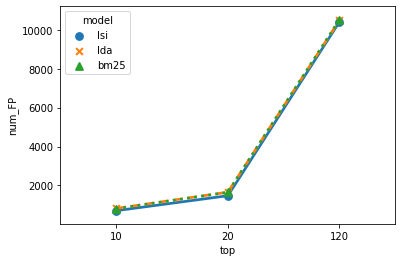

```python
from matplotlib import pyplot as plt
import seaborn as sns

sns.pointplot(y='num_FP', x='top',
              hue='model',
              col='retrieved',
              markers=['o','x','^','v','o'],
              linestyles=["-","--",":","-.","-"],
              data=retrieved_traces_df)
```

##### FP Details

```python
df_bm25_t10 = aux_functions.detail_features_tc_br(bm25_fp_exc_set_t10, testcases, bugreports)
df_bm25_t120 = aux_functions.detail_features_tc_br(bm25_fp_exc_set_t120, testcases, bugreports)

bm25_t10_fp_amount_by_feat = df_bm25_t10.groupby('tc_feat').count()
bm25_t120_fp_amount_by_feat = df_bm25_t120.groupby('tc_feat').count()
bm25_t10_fp_amount_by_feat['model'] = 'bm25'
bm25_t120_fp_amount_by_feat['model'] = 'bm25'


df_lda_t10 = aux_functions.detail_features_tc_br(lda_fp_exc_set_t10, testcases, bugreports)
df_lda_t120 = aux_functions.detail_features_tc_br(lda_fp_exc_set_t120, testcases, bugreports)

lda_t10_fp_amount_by_feat = df_lda_t10.groupby('tc_feat').count()
lda_t120_fp_amount_by_feat = df_lda_t120.groupby('tc_feat').count()
lda_t10_fp_amount_by_feat['model'] = 'lda'
lda_t120_fp_amount_by_feat['model'] = 'lda'


df_lsi_t10 = aux_functions.detail_features_tc_br(lsi_fp_exc_set_t10, testcases, bugreports)
df_lsi_t120 = aux_functions.detail_features_tc_br(lsi_fp_exc_set_t120, testcases, bugreports)

lsi_t10_fp_amount_by_feat = df_lsi_t10.groupby('tc_feat').count()
lsi_t120_fp_amount_by_feat = df_lsi_t120.groupby('tc_feat').count()
lsi_t10_fp_amount_by_feat['model'] = 'lsi'
lsi_t120_fp_amount_by_feat['model'] = 'lsi'
```

```python
df_t10 = pd.concat([bm25_t10_fp_amount_by_feat, lsi_t10_fp_amount_by_feat,
                   lda_t10_fp_amount_by_feat])

df_t10 = df_t10[['tc','model']]
df_t10.reset_index(inplace=True)
df_t10.rename(columns={'tc':'FP_amount','tc_feat':'feature'}, inplace=True)
df_t10 = df_t10.pivot('feature','model','FP_amount')
df_t10.head(20)
```

| model feature | bm25 | lda | lsi |
| --- | --- | --- | --- |
| APZ - Async Scrolling | 16.0 | 21.0 | 15.0 |
| Browser Customization | 47.0 | 3.0 | 53.0 |
| Context Menu | 63.0 | 352.0 | 52.0 |
| Downloads Dropmaker | 120.0 | 17.0 | 7.0 |
| FLAC support | 8.0 | NaN | 13.0 |
| Flash support | 3.0 | 2.0 | 5.0 |
| Indicator for device permissions | 77.0 | 90.0 | 59.0 |
| New Awesome Bar | 19.0 | 16.0 | 69.0 |
| PDF Viewer | 15.0 | 18.0 | 8.0 |
| Pointer Lock API | 51.0 | 20.0 | 7.0 |
| Text to Speech in Reader Mode | 12.0 | NaN | 21.0 |
| Text to Speech on Desktop | 6.0 | 1.0 | 7.0 |
| Web Page Renderization | 2.0 | 3.0 | 6.0 |
| WebGL Compatibility | 3.0 | 8.0 | 3.0 |
| WebGL2 | 2.0 | 19.0 | 7.0 |
| WebM EME support for Widevine | 24.0 | NaN | NaN |
| Windows 10 Compatibility | 13.0 | 6.0 | 39.0 |
| Windows Child Mode | 40.0 | 29.0 | 27.0 |
| Zoom Indicator | 11.0 | 15.0 | 10.0 |

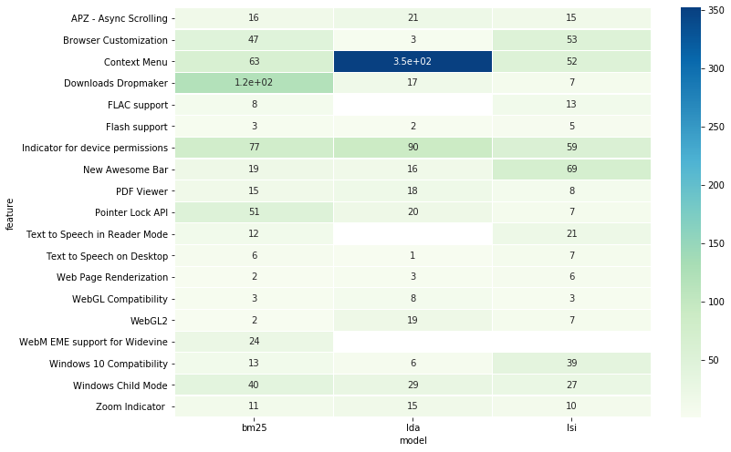

```python
import seaborn as sns
from matplotlib import pyplot as plt

a4_dims = (11.7, 8.27)
fig, ax = plt.subplots(figsize=a4_dims)
sns.heatmap(ax=ax, data=df_t10, linewidths=.3, annot=True, cmap='GnBu')
```

```python
df_t120 = pd.concat([bm25_t120_fp_amount_by_feat, lsi_t120_fp_amount_by_feat,
                     lda_t120_fp_amount_by_feat])

df_t120 = df_t120[['tc','model']]
df_t120.reset_index(inplace=True)
df_t120.rename(columns={'tc':'FP_amount','tc_feat':'feature'}, inplace=True)
df_t120 = df_t120.pivot('feature','model','FP_amount')
df_t120.head(20)
```

| model feature | bm25 | lda | lsi |
| --- | --- | --- | --- |
| APZ - Async Scrolling | 97 | 311 | 151 |
| Browser Customization | 36 | 42 | 40 |
| Context Menu | 39 | 384 | 26 |
| Downloads Dropmaker | 82 | 151 | 63 |
| FLAC support | 45 | 90 | 7 |
| Flash support | 23 | 16 | 14 |
| Indicator for device permissions | 55 | 119 | 44 |
| New Awesome Bar | 11 | 30 | 218 |
| PDF Viewer | 21 | 208 | 13 |
| Pointer Lock API | 156 | 21 | 123 |
| Text to Speech in Reader Mode | 94 | 7 | 88 |
| Text to Speech on Desktop | 5 | 7 | 23 |
| Web Page Renderization | 13 | 12 | 42 |
| WebGL Compatibility | 3 | 86 | 3 |
| WebGL2 | 8 | 108 | 2 |
| WebM EME support for Widevine | 116 | 28 | 15 |
| Windows 10 Compatibility | 11 | 55 | 43 |
| Windows Child Mode | 30 | 50 | 19 |
| Zoom Indicator | 263 | 111 | 130 |

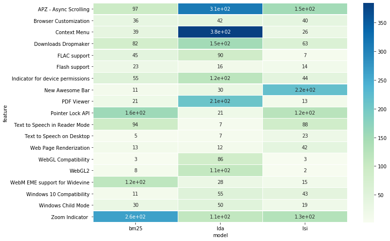

```python
import seaborn as sns
from matplotlib import pyplot as plt

a4_dims = (11.7, 8.27)
fig, ax = plt.subplots(figsize=a4_dims)
sns.heatmap(ax=ax, data=df_t120, linewidths=.3, annot=True, cmap='GnBu')
```

```python
aux_functions.detail_features_tc_br_groups(lsi_fp_exc_set_t120, testcases=testcases, bugreports=bugreports)
```

|  | br | br_summary | tc_feat | tc_ids |
| --- | --- | --- | --- | --- |
| 0 | 1248267 | Right click on bookmark item of "Recently Bookmarked" should show regular places context menu | Browser Customization | [60] |
| 1 | 1248267 | Right click on bookmark item of "Recently Bookmarked" should show regular places context menu | Downloads Dropmaker | [163, 153] |
| 2 | 1248267 | Right click on bookmark item of "Recently Bookmarked" should show regular places context menu | New Awesome Bar | [15, 25, 20, 22, 13, 21] |
| 3 | 1248267 | Right click on bookmark item of "Recently Bookmarked" should show regular places context menu | Text to Speech in Reader Mode | [112] |
| 4 | 1248267 | Right click on bookmark item of "Recently Bookmarked" should show regular places context menu | Web Page Renderization | [124, 123] |
| ... | ... | ... | ... | ... |
| 450 | 1449700 | refactor addTab/moveTabTo | Text to Speech in Reader Mode | [118] |
| 451 | 1451475 | Renew scalar browser.engagement.restored_pinned_tabs_count | Pointer Lock API | [125, 127, 129, 130, 132, 133] |
| 452 | 1451475 | Renew scalar browser.engagement.restored_pinned_tabs_count | Text to Speech in Reader Mode | [119] |
| 453 | 1451475 | Renew scalar browser.engagement.restored_pinned_tabs_count | Web Page Renderization | [123, 124] |
| 454 | 1451475 | Renew scalar browser.engagement.restored_pinned_tabs_count | Zoom Indicator | [146, 148, 199] |

455 rows × 4 columns

#### False Negatives Analysis

```python
bm25_fn_set_t10, lsi_fn_set_t10, lda_fn_set_t10 = aux_functions.get_traces_set(retrieved_traces_df, MODELS, 10, 'FN')
bm25_fn_set_t20, lsi_fn_set_t20, lda_fn_set_t20 = aux_functions.get_traces_set(retrieved_traces_df, MODELS, 20, 'FN')
bm25_fn_set_t120, lsi_fn_set_t120, lda_fn_set_t120 = aux_functions.get_traces_set(retrieved_traces_df, MODELS, 120, 'FN')

#aux_functions.plot_venn_diagrams(10, bm25_fn_set_t10, lsi_fn_set_t10, lda_fn_set_t10, 'FN')
#aux_functions.plot_venn_diagrams(40, bm25_fn_set_t40, lsi_fn_set_t40, lda_fn_set_t40, 'FN')
```

```python
df = pd.DataFrame(index=['TOP 10', 'TOP 20', 'TOP 120'], columns=['BM25','LSI','LDA'])

df.at['TOP 10','BM25'] = len(bm25_fn_set_t10)
df.at['TOP 20','BM25'] = len(bm25_fn_set_t20)
df.at['TOP 120','BM25'] = len(bm25_fn_set_t120)

df.at['TOP 10','LSI'] = len(lsi_fn_set_t10)
df.at['TOP 20','LSI'] = len(lsi_fn_set_t20)
df.at['TOP 120','LSI'] = len(lsi_fn_set_t120)

df.at['TOP 10','LDA'] = len(lda_fn_set_t10)
df.at['TOP 20','LDA'] = len(lda_fn_set_t20)
df.at['TOP 120','LDA'] = len(lda_fn_set_t120)

print()

df
```

|  | BM25 | LSI | LDA |
| --- | --- | --- | --- |
| TOP 10 | 404 | 302 | 418 |
| TOP 20 | 338 | 162 | 345 |
| TOP 120 | 117 | 13 | 93 |

##### Exclusive Traces

```python
print("TOP 10 ------------------------------")
bm25_fn_exc_set_t10, lsi_fn_exc_set_t10, lda_fn_exc_set_t10 =  aux_functions.get_exclusive_traces_expanded(bm25_fn_set_t10, lsi_fn_set_t10, lda_fn_set_t10, traces_type='FN')

print("\n\nTOP 20 -------------------------------")
bm25_fn_exc_set_t20, lsi_fn_exc_set_t20, lda_fn_exc_set_t20 =  aux_functions.get_exclusive_traces_expanded(bm25_fn_set_t20, lsi_fn_set_t20, lda_fn_set_t20, traces_type='FN')

print("\n\nTOP 120 -------------------------------")
bm25_fn_exc_set_t120, lsi_fn_exc_set_t120, lda_fn_exc_set_t120 =  aux_functions.get_exclusive_traces_expanded(bm25_fn_set_t120, lsi_fn_set_t120, lda_fn_set_t120, traces_type='FN')
```

```
TOP 10 ------------------------------


len(bm25_exc_set): 24
len(lsi_exc_set): 12
len(lda_exc_set): 40


TOP 20 -------------------------------


len(bm25_exc_set): 54
len(lsi_exc_set): 9
len(lda_exc_set): 61


TOP 120 -------------------------------


len(bm25_exc_set): 54
len(lsi_exc_set): 11
len(lda_exc_set): 31
```

##### FN Details

```python
df_bm25_t10 = aux_functions.detail_features_tc_br(bm25_fn_exc_set_t10, testcases, bugreports)
df_bm25_t120 = aux_functions.detail_features_tc_br(bm25_fn_exc_set_t120, testcases, bugreports)

bm25_t10_fn_amount_by_feat = df_bm25_t10.groupby('tc_feat').count()
bm25_t120_fn_amount_by_feat = df_bm25_t120.groupby('tc_feat').count()
bm25_t10_fn_amount_by_feat['model'] = 'bm25'
bm25_t120_fn_amount_by_feat['model'] = 'bm25'


df_lda_t10 = aux_functions.detail_features_tc_br(lda_fn_exc_set_t10, testcases, bugreports)
df_lda_t120 = aux_functions.detail_features_tc_br(lda_fn_exc_set_t120, testcases, bugreports)

lda_t10_fn_amount_by_feat = df_lda_t10.groupby('tc_feat').count()
lda_t120_fn_amount_by_feat = df_lda_t120.groupby('tc_feat').count()
lda_t10_fn_amount_by_feat['model'] = 'lda'
lda_t120_fn_amount_by_feat['model'] = 'lda'


df_lsi_t10 = aux_functions.detail_features_tc_br(lsi_fn_exc_set_t10, testcases, bugreports)
df_lsi_t120 = aux_functions.detail_features_tc_br(lsi_fn_exc_set_t120, testcases, bugreports)

lsi_t10_fn_amount_by_feat = df_lsi_t10.groupby('tc_feat').count()
lsi_t120_fn_amount_by_feat = df_lsi_t120.groupby('tc_feat').count()
lsi_t10_fn_amount_by_feat['model'] = 'lsi'
lsi_t120_fn_amount_by_feat['model'] = 'lsi'
```

###### TOP 10

```python
df_t10 = pd.concat([bm25_t10_fn_amount_by_feat,  lsi_t10_fn_amount_by_feat,
                     lda_t10_fn_amount_by_feat])

df_t10 = df_t10[['tc','model']]
df_t10.reset_index(inplace=True)
df_t10.rename(columns={'tc':'FN_amount','tc_feat':'feature'}, inplace=True)
df_t10 = df_t10.pivot('feature','model','FN_amount')
df_t10.head(20)
```

| model feature | bm25 | lda | lsi |
| --- | --- | --- | --- |
| Browser Customization | NaN | 2.0 | NaN |
| Context Menu | 5.0 | 2.0 | 3.0 |
| Downloads Dropmaker | 4.0 | 11.0 | 6.0 |
| Indicator for device permissions | 3.0 | 6.0 | 2.0 |
| New Awesome Bar | 12.0 | 17.0 | NaN |
| PDF Viewer | NaN | 1.0 | 1.0 |
| Zoom Indicator | NaN | 1.0 | NaN |

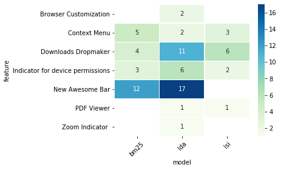

```python
import seaborn as sns
from matplotlib import pyplot as plt

a4_dims = (5, 4)
fig, ax = plt.subplots(figsize=a4_dims)
sns.heatmap(ax=ax, data=df_t10, linewidths=.3, annot=True, cmap='GnBu')
plt.xticks(rotation=45)
```

###### TOP 120

```python
df_t120 = pd.concat([bm25_t120_fn_amount_by_feat, lsi_t120_fn_amount_by_feat,
                     lda_t120_fn_amount_by_feat])

df_t120 = df_t120[['tc','model']]
df_t120.reset_index(inplace=True)
df_t120.rename(columns={'tc':'FN_amount','tc_feat':'feature'}, inplace=True)
df_t120 = df_t120.pivot('feature','model','FN_amount')
df_t120.head(20)
```

| model feature | bm25 | lda | lsi |
| --- | --- | --- | --- |
| Browser Customization | NaN | 5.0 | 1.0 |
| Context Menu | 1.0 | NaN | 1.0 |
| Downloads Dropmaker | NaN | NaN | 4.0 |
| New Awesome Bar | 53.0 | 26.0 | 5.0 |

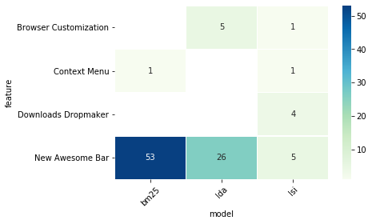

```python
import seaborn as sns
from matplotlib import pyplot as plt

a4_dims = (6, 4)
fig, ax = plt.subplots(figsize=a4_dims)
ax = sns.heatmap(ax=ax, data=df_t120, linewidths=.3, annot=True, cmap='GnBu')
plt.xticks(rotation=45)
```

**LSI Exclusive FN Top 120**

```python
aux_functions.detail_features_tc_br_groups(lsi_fn_exc_set_t120, testcases, bugreports).sort_values(by='tc_feat')
```

|  | br | br_summary | tc_feat | tc_ids |
| --- | --- | --- | --- | --- |
| 5 | 1357458 | After Customization - typed text in the Awesome bar doesn't correspond with the text from One-Off-Searches bar | Browser Customization | [63] |
| 0 | 1270983 | Intermittent browser_contextmenu.jsTest timed outFound a tab after previous test timed out: subtst_contextmenu.html - | Context Menu | [77] |
| 6 | 1432915 | Do not write the kMDItemWhereFroms xattr metadata for files downloaded in Private Browsing mode | Downloads Dropmaker | [157, 155, 169, 154] |
| 1 | 1276120 | Autocomplete suggestions just don't go away after Win+Down | New Awesome Bar | [14] |
| 2 | 1279143 | color indicator missing when "File -> New Container Tab" without any windows opened | New Awesome Bar | [14, 16] |
| 3 | 1296366 | Ctrl+Click awesomebar entry with "Switch to Tab" doesn't open new tab | New Awesome Bar | [14] |
| 4 | 1337682 | using ctrl / shift + enter seems to save the URL to a hidden clipboard that populates when hitting enter (hard to describe). | New Awesome Bar | [14] |

**BM25 Exclusive FN Top 120**

```python
aux_functions.detail_features_tc_br_groups(bm25_fn_exc_set_t120, testcases, bugreports).sort_values(by='tc_feat')
```

|  | br | br_summary | tc_feat | tc_ids |
| --- | --- | --- | --- | --- |
| 1 | 1270983 | Intermittent browser_contextmenu.jsTest timed outFound a tab after previous test timed out: subtst_contextmenu.html - | Context Menu | [75] |
| 0 | 1264988 | Scrollbar appears for a moment in the new Awesomebar Resultlist | New Awesome Bar | [15] |
| 15 | 1353831 | OneOff block in search bar doesn't update text if Customize was opened at least once | New Awesome Bar | [19, 22, 23, 21, 25, 20] |
| 14 | 1352539 | Move defaultenginename pref setting into list.json | New Awesome Bar | [19, 25, 21, 22, 24, 20] |
| 13 | 1339497 | firefox tries to load incorrect url if urlbar autocomplete suggests first-two-letters-duplicated hosts when input url contains % encoded components | New Awesome Bar | [17, 16] |
| 12 | 1337682 | using ctrl / shift + enter seems to save the URL to a hidden clipboard that populates when hitting enter (hard to describe). | New Awesome Bar | [17, 13, 15, 16] |
| 11 | 1335992 | Search with default search engine stops working | New Awesome Bar | [20, 21, 25, 22] |
| 10 | 1334844 | Address bar uses most recently entered URL, not URL in bar, after using CTRL+ENTER | New Awesome Bar | [25, 15] |
| 9 | 1311998 | [One-off searches] Right click on a result from Awesomebar closes the dropdown | New Awesome Bar | [20, 21, 22] |
| 8 | 1301421 | browser.fixup.dns_first_for_single_words prevents location bar search suggestions even when there's more than one token and/or the first token is not a single word | New Awesome Bar | [24] |
| 7 | 1297976 | [One-off searches] Screen reader does not read the one-offs searches buttons | New Awesome Bar | [20, 21, 22, 19] |
| 6 | 1294887 | Middle clicking search results does not open a new tab | New Awesome Bar | [21, 20, 22] |
| 5 | 1294733 | Awesomebar search buttons show auto completed text not user input | New Awesome Bar | [22, 24, 21, 20, 25] |
| 4 | 1279864 | The new location bar autocomplete drop down menu starting from 48 has serious performance issue and often blocks user's <Enter> input | New Awesome Bar | [15] |
| 3 | 1279143 | color indicator missing when "File -> New Container Tab" without any windows opened | New Awesome Bar | [25, 15, 23, 24] |
| 2 | 1276120 | Autocomplete suggestions just don't go away after Win+Down | New Awesome Bar | [17] |
| 16 | 1357458 | After Customization - typed text in the Awesome bar doesn't correspond with the text from One-Off-Searches bar | New Awesome Bar | [20, 21, 22] |
| 17 | 1365887 | Can't open resource:///modules/ from the location bar | New Awesome Bar | [16, 13, 17] |

**LDA Exclusive FN Top 120**

```python
aux_functions.detail_features_tc_br_groups(lda_fn_exc_set_t120, testcases, bugreports).sort_values(by='tc_feat')
```

|  | br | br_summary | tc_feat | tc_ids |
| --- | --- | --- | --- | --- |
| 11 | 1357458 | After Customization - typed text in the Awesome bar doesn't correspond with the text from One-Off-Searches bar | Browser Customization | [59, 64, 60, 62, 61] |
| 0 | 1264988 | Scrollbar appears for a moment in the new Awesomebar Resultlist | New Awesome Bar | [19, 13, 23] |
| 1 | 1276120 | Autocomplete suggestions just don't go away after Win+Down | New Awesome Bar | [24] |
| 2 | 1279143 | color indicator missing when "File -> New Container Tab" without any windows opened | New Awesome Bar | [13] |
| 3 | 1279864 | The new location bar autocomplete drop down menu starting from 48 has serious performance issue and often blocks user's <Enter> input | New Awesome Bar | [13, 23, 18] |
| 4 | 1293308 | System font setting respected by location bar but ignored by location bar's autocomplete drop-down list | New Awesome Bar | [25] |
| 5 | 1296366 | Ctrl+Click awesomebar entry with "Switch to Tab" doesn't open new tab | New Awesome Bar | [13, 24] |
| 6 | 1301421 | browser.fixup.dns_first_for_single_words prevents location bar search suggestions even when there's more than one token and/or the first token is not a single word | New Awesome Bar | [18, 13, 15] |
| 7 | 1334844 | Address bar uses most recently entered URL, not URL in bar, after using CTRL+ENTER | New Awesome Bar | [23, 18, 22, 19] |
| 8 | 1337682 | using ctrl / shift + enter seems to save the URL to a hidden clipboard that populates when hitting enter (hard to describe). | New Awesome Bar | [25, 18] |
| 9 | 1339497 | firefox tries to load incorrect url if urlbar autocomplete suggests first-two-letters-duplicated hosts when input url contains % encoded components | New Awesome Bar | [23, 18, 13, 22] |
| 10 | 1352539 | Move defaultenginename pref setting into list.json | New Awesome Bar | [17] |
| 12 | 1365887 | Can't open resource:///modules/ from the location bar | New Awesome Bar | [24] |

### Recovery Effort Index (REI)

```python
orc_vol_only_precision = 42.66
def calculate_rei(row):
    if row['precision'] > 0:
        return orc_vol_only_precision/row['precision']
    return 0
```

```python
retrieved_traces_df['rei'] = retrieved_traces_df.apply(lambda row : calculate_rei(row), axis=1)
retrieved_traces_df[['top','model','precision','recall','rei']].groupby('model').rei.mean()
```

```
model
bm25    6.564061
lda     6.562483
lsi     4.443603
Name: rei, dtype: float64
```

### Goodness Scale

```python
aux_functions.calculate_goodness(evals_df_2, models=MODELS)
```

|  | model | precision | recall | fscore | goodness |
| --- | --- | --- | --- | --- | --- |
| 0 | bm25 | 10.60 | 28.64 | 16.68 | - |
| 1 | lsi | 27.62 | 47.61 | 31.32 | - |
| 2 | lda | 7.77 | 32.17 | 16.18 | - |